# How many pebbles are in the jar? Simulations in R

Jesus E. Vazquez

UMD School of Public Health teaching demonstration, October 28, 2026

These simulations go with the slides at thevazquezlab.com/talks. Every chunk runs in base R; copy and paste the code to try other values.

# 1. The binomial distribution

Our clinic example: $n = 4$ patients, and each one tests positive with probability $p = 0.25$.

```r
n <- 4
p <- 0.25

dbinom(0:n, size = n, prob = p)   # P(X = k) for k = 0, ..., 4
```

```
#> [1] 0.31640625 0.42187500 0.21093750 0.04687500 0.00390625
```

```r
choose(4, 1)                      # number of ways to get exactly one positive
```

```
#> [1] 4
```

```r
pbinom(1, size = n, prob = p)     # P(X <= 1)
```

```
#> [1] 0.7382812
```

```r
c(mean = n * p, variance = n * p * (1 - p))
```

```
#>     mean variance
#>     1.00     0.75
```

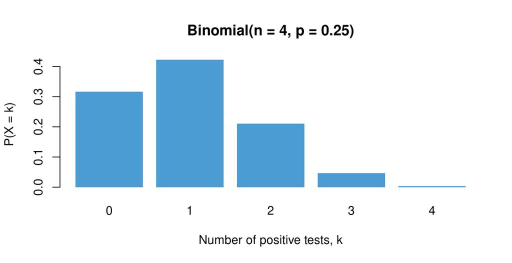

```r
barplot(dbinom(0:n, n, p), names.arg = 0:n, col = accent, border = NA,
        xlab = "Number of positive tests, k", ylab = "P(X = k)",
        main = "Binomial(n = 4, p = 0.25)")
```

# 2. The jar

The jar holds $N = 200$ objects. After the first toss we have swapped in $M = 50$ blue cubes. On the second toss $n = 40$ objects land inside the circle, and each one is a cube with probability $p = M/N$. The number of cubes in the circle, $X$, is binomial, and the Lincoln–Petersen estimator is $\hat N = Mn/k$.

```r
set.seed(2026)
N <- 200   # true total (unknown in practice)
M <- 50    # cubes swapped in
n <- 40    # objects in the circle on the second toss

k <- rbinom(1, size = n, prob = M / N)   # cubes in the circle
k
```

```
#> [1] 11
```

```r
M * n / k                                # one estimate of N
```

```
#> [1] 181.8182
```

Now repeat the experiment 1,000 times.

```r
R <- 1000
k <- rbinom(R, size = n, prob = M / N)
N_hat <- ifelse(k > 0, M * n / k, NA)

summary(N_hat)
```

```
#>    Min. 1st Qu.  Median    Mean 3rd Qu.    Max.
#>   105.3   166.7   200.0   219.1   250.0   666.7
```

```r
quantile(N_hat, c(0.05, 0.95), na.rm = TRUE)   # middle 90% of the estimates
```

```
#>       5%      95%
#> 142.8571 336.6667
```

```r
mean(N_hat >= 150 & N_hat <= 250, na.rm = TRUE)  # share within 150 to 250
```

```
#> [1] 0.71
```

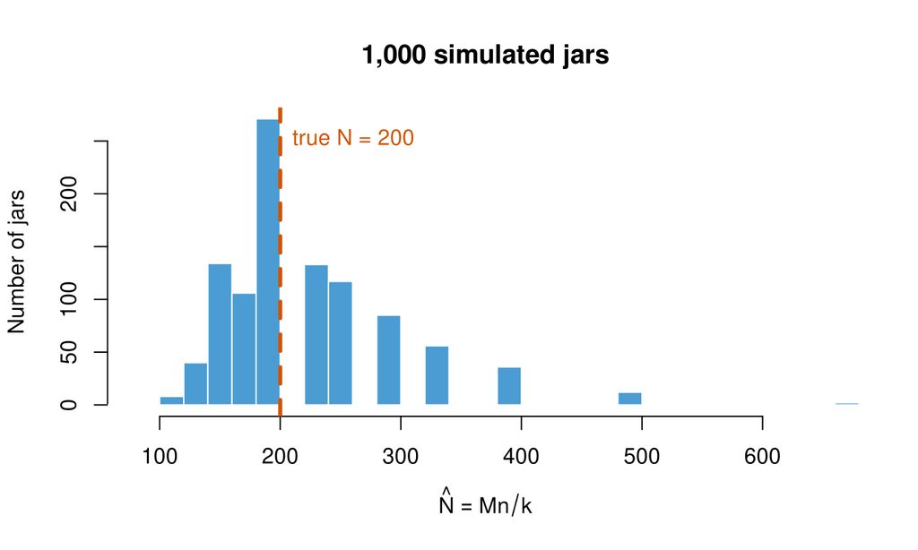

```r
hist(N_hat, breaks = seq(0, 1000, by = 20), xlim = c(80, 660),
     col = accent, border = "white", main = "1,000 simulated jars",
     xlab = expression(hat(N) == Mn/k), ylab = "Number of jars")
abline(v = N, col = hl, lwd = 3, lty = 2)
text(N + 10, par("usr")[4] * 0.9, "true N = 200", col = hl, adj = 0)
```

The estimates pile up near 200 but have a long right tail: a few unlucky tosses with few cubes in the circle give very large estimates.

# 3. What does a bigger second toss buy?

```r
sim_jar <- function(n, R = 1000) {
  k <- rbinom(R, size = n, prob = M / N)
  ifelse(k > 0, M * n / k, NA)
}
est_40  <- sim_jar(40)
est_100 <- sim_jar(100)

rbind("n = 40"  = quantile(est_40,  c(0.05, 0.95), na.rm = TRUE),
      "n = 100" = quantile(est_100, c(0.05, 0.95), na.rm = TRUE))
```

```
#>               5%      95%
#> n = 40  133.3333 333.3333
#> n = 100 156.2500 277.7778
```

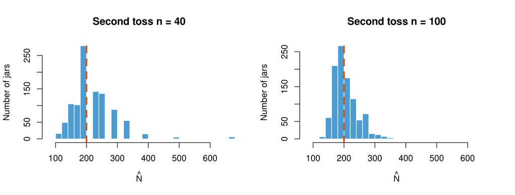

```r
par(mfrow = c(1, 2))
for (v in list(list(est_40, "Second toss n = 40"), list(est_100, "Second toss n = 100"))) {
  hist(v[[1]], breaks = seq(0, 1000, by = 20), xlim = c(80, 660), col = accent,
       border = "white", main = v[[2]], xlab = expression(hat(N)), ylab = "Number of jars")
  abline(v = N, col = hl, lwd = 3, lty = 2)
}
```

A bigger second toss narrows the spread of the estimates around the true total.

# 4. Two clinics

Now the “jar” is a population of $N = 180$ people. Clinic A’s list plays the role of the cubes ($M$), clinic B’s list plays the role of the second toss ($n$), and people on both lists are the cubes in the circle ($k$). The function below simulates both lists under four scenarios.

```r
sim_clinics <- function(scenario, N = 180, R = 1000) {
  est <- numeric(R)
  for (r in 1:R) {
    if (scenario == "Independent lists") {
      a <- runif(N) < 1/3
      b <- runif(N) < 1/4
    } else if (scenario == "Referral") {
      # people on A's list are often referred to B
      a <- runif(N) < 1/3
      b <- ifelse(a, runif(N) < 0.5, runif(N) < 0.167)
    } else if (scenario == "Hard-to-reach group") {
      # 60 people rarely reach either clinic
      hard <- seq_len(N) <= 60
      a <- runif(N) < ifelse(hard, 0.10, 0.43)
      b <- runif(N) < ifelse(hard, 0.10, 0.33)
    } else if (scenario == "Separate catchments") {
      # half live near clinic B, half near clinic A
      near_b <- seq_len(N) <= N / 2
      a <- runif(N) < ifelse(near_b, 0.10, 0.55)
      b <- runif(N) < ifelse(near_b, 0.50, 0.10)
    }
    k <- sum(a & b)
    est[r] <- if (k > 0) sum(a) * sum(b) / k else NA
  }
  est
}
```

```r
set.seed(2026)
scenarios <- c("Independent lists", "Referral", "Hard-to-reach group", "Separate catchments")
res <- lapply(scenarios, sim_clinics)
names(res) <- scenarios

data.frame(median = sapply(res, median, na.rm = TRUE),
           share_below_180 = sapply(res, function(v) mean(v < 180, na.rm = TRUE)))
```

```
#>                      median share_below_180
#> Independent lists   180.000           0.496
#> Referral            100.000           1.000
#> Hard-to-reach group 148.775           0.856
#> Separate catchments 340.100           0.001
```

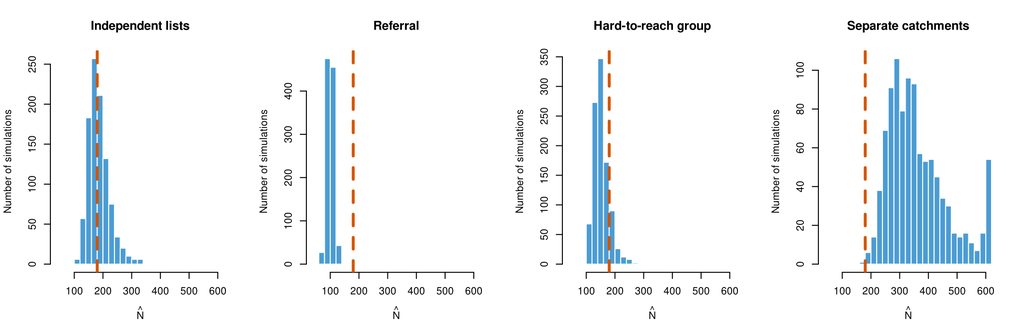

```r
par(mfrow = c(1, 4))
for (s in scenarios) {
  hist(pmin(res[[s]], 610), breaks = seq(40, 620, by = 20), col = accent,
       border = "white", main = s, xlab = expression(hat(N)), ylab = "Number of simulations")
  abline(v = 180, col = hl, lwd = 3, lty = 2)
}
```

When the two lists are independent, the estimates center on the true total of 180. Referral and a hard-to-reach group make the lists overlap too much, so the estimator falls short; separate catchments make the lists overlap too little, so the estimator overshoots.